# Report of Russian military action in the Ukraine War

Joshua, Benedict, Derek, Fan

2022-05-20

## Introduction

As the Ukraine War is moving toward the fifth month, we want to interpret the war through the eyes of statistics. This report will present the condition on the battlefield using data set of the Russian equipment loss. We hope to provide readers with some key takeaway to help them understand more about the war.

## Summary

In the data set we have selected, it recorded the loss of equipments during the Russian Ukrainian War. With this information, we were able to analyze and figure out six important values that are beneficial for understanding the war. First, we calculated the exact number of days, which is  
**83** in this case, that the wars have taken place. It helps the audience to have a precise understanding of the longevity of this war. Further, we also figured out the number of weeks that the war has taken place, which is **12**, so the audience can have a better understanding of the time frame with a glance as weeks are generally easier to visualize given the small value it correspond with comparing to days. Besides, we also managed to find day when most of aircraft were lost, which is **2022-02-26**, so we can have a better understanding of which day that the war is most intensive. Furthermore, we also managed to find day when most of drone were lost, which is **2022-05-02**, so we can have a better understanding of which day that Russian were most intensively spying. Beyond that, we think it would also be crucial to see the total lost in tank, which is **1235**, so the audience can have a clear understanding of the material lost due to this war. Last but not least, even though both countries have fought on land, there does seem to be **13** of Naval Ship lost based on our investigation.

## Aggregate Table

| month | aircraft_loss | helicopter_loss | tank_loss | APC_loss | field_artillery_loss | MRL_loss | drone_loss | anti_aircraft_warfare_loss |
| --- | --- | --- | --- | --- | --- | --- | --- | --- |
| 2022-02 | 93 | 88 | 526 | 2744 | 222 | 33 | 7 | 5 |
| 2022-03 | 2472 | 2913 | 12998 | 41083 | 5928 | 2123 | 774 | 1129 |
| 2022-04 | 4926 | 4331 | 23478 | 61343 | 11136 | 3749 | 4397 | 1896 |
| 2022-05 | 3364 | 2699 | 19470 | 47034 | 8792 | 3041 | 6087 | 1449 |

## Indensity of the War

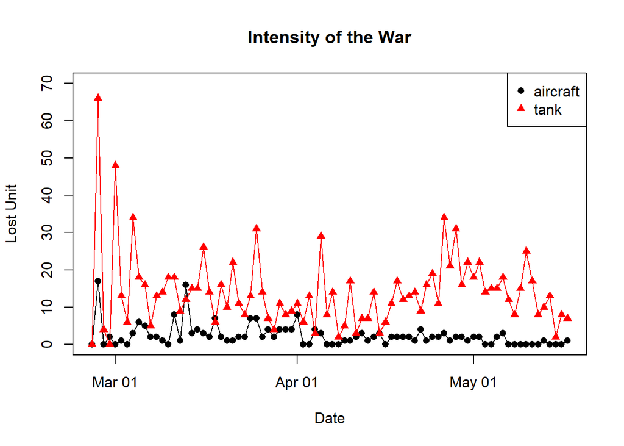

## Trend of Aircraft Losses

This chart analyze and visualize the the lost of aircraft in each day and to analyze the trend of it. According to the graph, we can see that with the war keep going, the loses of aircraft in a single day showing a decreasing trend.

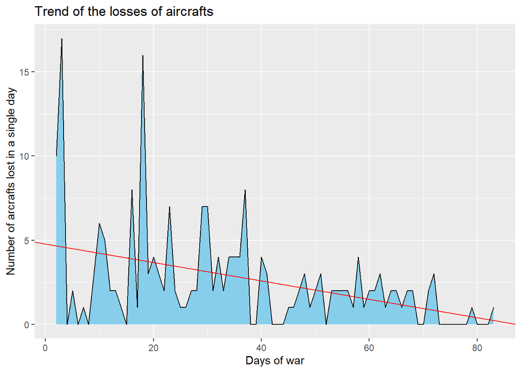

## APC Losing percentage

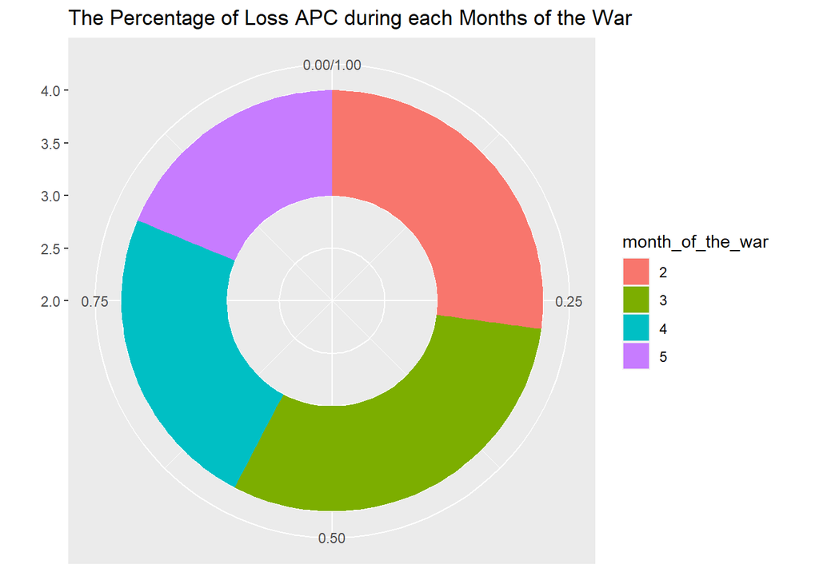